# Four principles for improved statistical ecology: a worked example for species richness in wetland mesocosms

Underground mining is known to disrupt surface and groundwater flows which may affect nearby swamp communities. The researchers wanted to examine how differing water availability affected swamp plant communities, both alone and in combination with a fire disturbance. For this study, researchers planned to collect from multiple swamps, then randomise them to water and fire treatments in a glasshouse to infer if water availability causes changes in richness. Mesocosms, for the purpose of this study, are a column of soil and plants, collected by hammering PVC pipe (diameter of 150 mm and a depth of 250 mm) to ground level and extracted with trenching shovels. They would then placed in tubs in a glasshouse, and tub water levels were manipulated to simulate different levels of groundwater availability. A fire event was to be simulated by sequentially applying biomass removal (clipping), heat and smoke to half of the mesocosms in each water treatment after 20 months (see Figure 1 main manuscript).

The example below is a simplified portion of the full experiment and analysis in (Mason et al., 2022)

## Principle 1. First, define a focused research question, then plan sampling and analysis to answer it

### 1A – Define your research question

#### FINER

- **Feasible** - There is enough funding and expertise to conduct a 3.5 year glasshouse experiment with about 250 mesocosms.
- **Interesting** - Swamp communities are likely to be sensitive to changes in the hydrological gradient and fire regime (Keith et al., 2010; Keith et al., 2022) and recent longwall underground coal extraction has caused subsidence, diminishing water resources (Mason et al., 2021).
- **Novel** - Current evidence is from observational studies, no controlled empirical manipulations have been undertaken, and this would add substantially to the evidence base.
- **Ethical** - Extraction of small mesocosms is unlikely to have a negative effect on the health of the ecosystem.
- **Relevant** - Underground coal mining is active in the Southern Coalfield of the Sydney Basin. Understanding the compounding effects of hydrological and fire disturbance will assist conservation of endangered upland swamp communities.

#### Predictions

- Mesocosms with low water resource availability will have reduced species richness over time compared with mesocosms with high water resource availability.
- Low water resource availability will compound fire effects (interaction).

Note - We will assume burnt vegetation will have greater reduction in richness than unburnt vegetation, and this is not of interest.

#### PICO

- **Population** - Upland swamp plant communities of the Sydney Basin bioregion, Australia
- **Intervention** - Two interventions: water availability (low, medium, high) and fire (yes, no), factorial.
- **Comparison** - The control group is high water unburnt mesocosms, as this group is considered to reflect the natural (unburnt) state of the swamps, though differences between all treatments are of interest.
- **Outcome** - Richness (# species)

### 1B – Match data collection to research aims

#### Field Sampling

1. Researchers collected 31 mesocosms comprising above-ground and root biomass along with soil material from both cyperoid heath and Ti-tree thicket vegetation communities in each of four upland swamps in the Sydney Basin.
2. Above-ground vegetation was clipped to approximately 10% of the original biomass and mesocosms were bagged and then transported to the glasshouse. Mesocosms from each site were allowed to acclimatise for a 28 days, with regular watering prior to treatment allocation.

#### Manipulative Experiment

1. Mesocosms were randomised to high, medium or low water availability treatment levels, and burnt or unburnt fire treatment levels.

To do this we need the `randomizr` package, and a list of mesocosms.

```r
library(randomizr)
mesocosms <- read.csv("../data/mesocosms.csv")
head(mesocosms)
```

```
##         Sod Swamp veg
## 1 CAT_CH_01    CA  ch
## 2 CAT_CH_02    CA  ch
## 3 CAT_CH_03    CA  ch
## 4 CAT_CH_04    CA  ch
## 5 CAT_CH_05    CA  ch
## 6 CAT_CH_06    CA  ch
```

The simplest way to randomize is complete random assignment, where each mesocosm is allocated to each treatment with some probability. If we want equal probabilities for each treatment then with 6 treatments (3 water x 2 fire) we use `prob_each = rep(1/6,6)`)

```r
mesocosms$treatment = complete_ra(N = nrow(mesocosms), prob_each = rep(1/6,6),
                                  conditions = c("H_u", "M_u", "L_u", "H_b", "M_b", "L_b"))
head(mesocosms)
```

```
##         Sod Swamp veg treatment
## 1 CAT_CH_01    CA  ch       H_b
## 2 CAT_CH_02    CA  ch       L_b
## 3 CAT_CH_03    CA  ch       H_b
## 4 CAT_CH_04    CA  ch       L_b
## 5 CAT_CH_05    CA  ch       L_b
## 6 CAT_CH_06    CA  ch       M_b
```

We can check how many mesocosms are in each treatment.

```r
table(mesocosms$treatment)
```

```
##
## H_u M_u L_u H_b M_b L_b
##  41  41  41  42  41  42
```

2. For the duration of the experiment, water levels of treatment tubs were maintained at 70, 155 and 240 mm below the mesocosm surface for the high, medium and low water availability levels, respectively.
3. A single fire event was simulated in mesocosms allocated to the burnt treatment by sequentially clipping, heating and applying smoked water to these mesocosms.
4. Richness was measured at interval throughout the experiment.

### 1C – Plan analysis and consider registration

#### Model

- (Generalised) linear mixed model with richness as outcome, fixed effects for swamp and vegetation type to control for these, and random effect for mesocosm (to account for repeated measures), as well as fixed effects for time (categorical), water (low, medium, high), and fire (burnt, unburnt).
- Outcome type (normal, log transfomed etc.), and relationship type (linear, quadratic) to be determined with reference to residual plots.

#### Primary Effects of interest (with confidence intervals)

- Effect of **water availability** on change in richness on unburnt mesocosms, controlling for swamp and vegetation type. Planned contrasts of change between water availability levels at 2 years (immediately prior to burning) to 4 years (conclusion of experiment).
- Effect of **burning** on difference in richness among **water availability levels**, controlling for swamp, vegetation type and water availability treatment. Planned contrast between burnt and unburnt at 4 years (conclusion of experiment),

#### Multiple testing

- Primary effects p-values and confidence intervals will be adjusted for multiple testing using the multivariate t distribution (`method = "mvt"` in `emmeans`)

## Principle 2. Develop a model that accounts for the distribution and dependence of your data

### 2A – Model dependence

We have three sources of dependence

1. Mesocosms come from four swamps, and different swamps may have different richness values. We therefore include a fixed effect of swamp.
2. Mesocosms are from two vegetation communities (Ti-tree thicket and Cyperoid heath), and these communities may differ in richness. So we will include a fixed effect for vegetation community.
3. Mesocosms will be measured multiple times, and these repeated measurements will be correlated. So we will include a random intercept for mesocosm.

#### Read in richness data

```r
rich_data <- read.csv("../data/rich_data.csv")
```

#### Mixed model

```r
library(lme4)
rich_live <- lmer(richness ~ swamp + veg +
                    factor(days)*water_treatment +
                    factor(days)*fire_treatment +
                    water_treatment*fire_treatment  +
                    (1 | Mesocosm),
                  data = rich_data)
```

### 2B – Check assumptions

#### Residual v.s. fitted plot (marginal)

Note - `re.form = NA` gives marginal residuals.

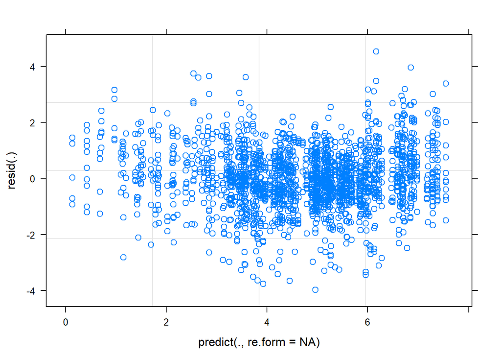

```r
plot(rich_live, resid(. ) ~ predict(., re.form = NA))
```

#### Scale-location plot

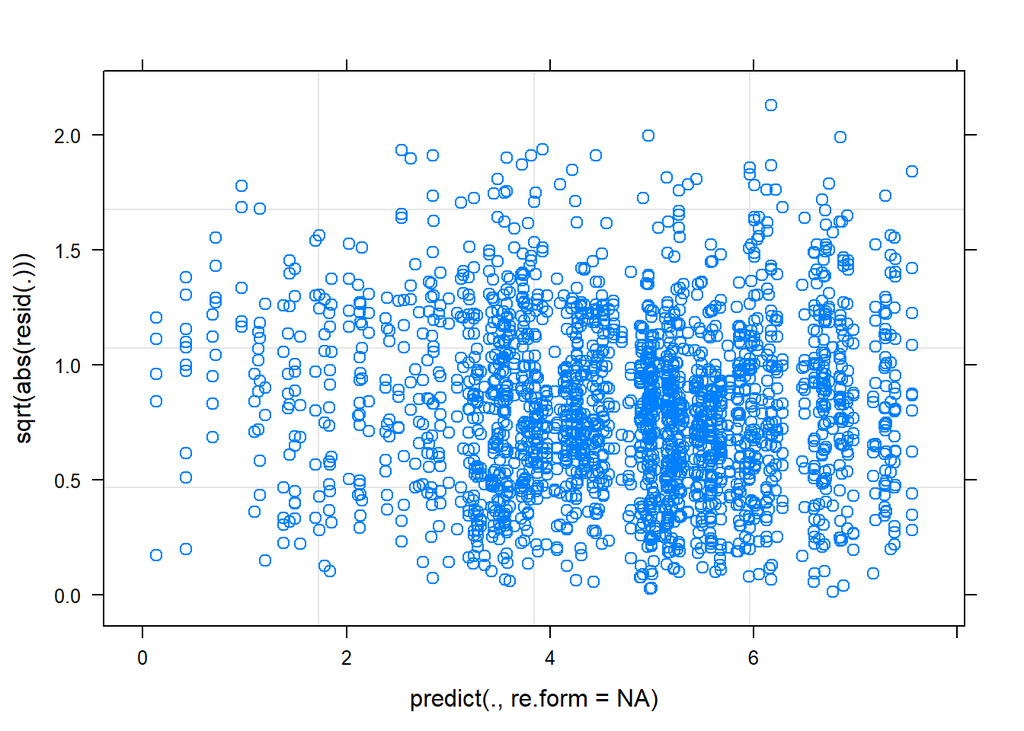

```r
plot(rich_live, sqrt(abs(resid(. ))) ~ predict(., re.form = NA))
```

Assumptions of linearity and constant variance are satisfied.

### 3A – Replace statistical significance with ecological relevance by emphasising effect sizes

Start by plotting model estimates. The easiest way is to use `emmip` from `emmeans`.

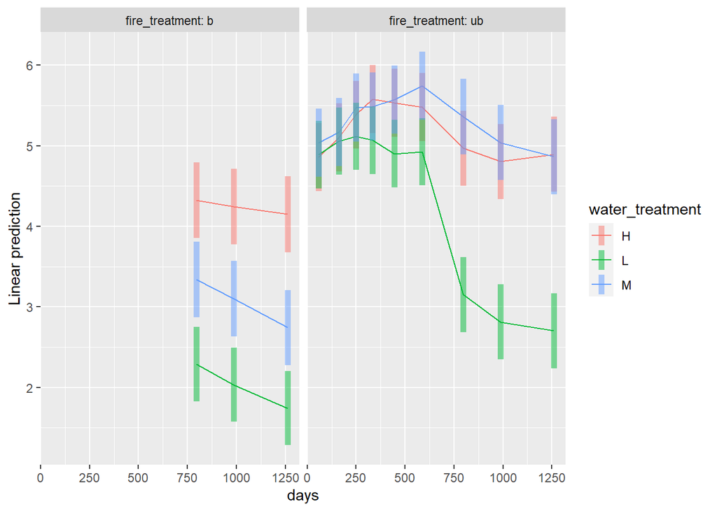

```r
library(emmeans)
emmeans_plot = emmip(rich_live,  ~ water_treatment ~ days | fire_treatment ,
                     CIs = TRUE) # always include confidence intervals
emmeans_plot
```

We can take the data from the previous plot and use them to make a prettier plot.

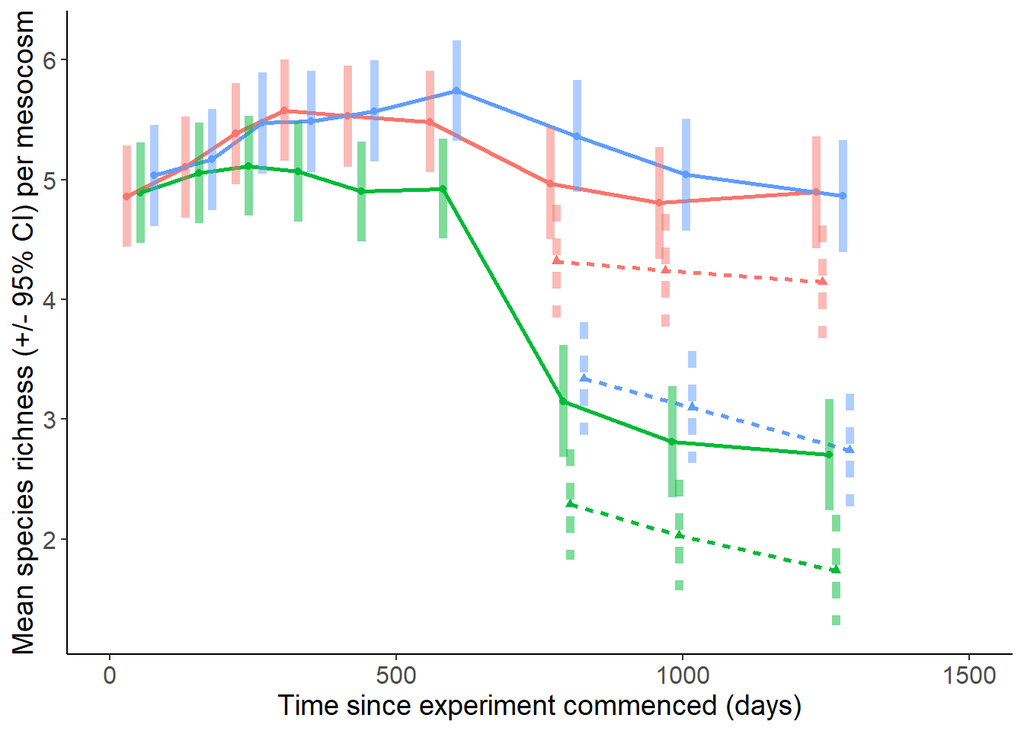

```r
library(ggplot2)
library(dplyr)

pos = position_dodge(width=70) # dodge water

plot_df <- emmeans_plot$data %>%
  mutate(fire_treatment = relevel(fire_treatment,"ub"))

ggplot(plot_df, aes(days, yvar, color = water_treatment,
             shape = fire_treatment, linetype = fire_treatment))+
  geom_point( position = pos, linewidth = 2 ) +
  geom_path( position = pos , linewidth = 1) +
  geom_errorbar(aes(ymin = LCL, ymax = UCL), position = pos,
                alpha = 0.5, width = 0, linewidth = 2) +
  theme_classic() +
  xlim(0,1500) +
  xlab("Time since experiment commenced (days)") +
  ylab("Mean species richness (+/- 95% CI) per mesocosm") +
  theme(legend.position = "none",
        axis.text = element_text( size = 12),
        axis.title = element_text( size = 14))
```

Next we calculate the desired effects and their confidence intervals, again using emmeans.

Estimate the marginal means for all water treatments, at just the times of interest (587 days and 1261 days), for unburnt mesocosms using the emmeans function.

```r
# water by time changes
em_water <- emmeans(rich_live,  ~ water_treatment + days ,
                    at = list(days = c(587,1261), fire_treatment = "ub"))
```

Calculate all pairwise interactions between the two.

```r
water_changes <- contrast(em_water, interaction = "pairwise", adjust = "mvt")
water_changes
```

```
##  water_treatment_pairwise days_pairwise estimate    SE   df t.ratio p.value
##  H - L                    587 - 1261      -1.635 0.271 1974 -6.027  <.0001
##  H - M                    587 - 1261      -0.291 0.272 1973 -1.068  0.5341
##  L - M                    587 - 1261       1.344 0.272 1974  4.943  <.0001
##
## Results are averaged over the levels of: swamp, veg
## Degrees-of-freedom method: kenward-roger
## P value adjustment: mvt method for 3 tests
```

Also estimate the means for all water and fire treatment combinations at the last time point (1261 days).

```r
# fire by water changes
em_fire <- emmeans(rich_live,  ~ water_treatment + fire_treatment ,
                   at = list(days = c(1261)))
```

Again calculate all pairwise interactions.

```r
fire_changes <- contrast(em_fire, interaction = "pairwise", adjust = "mvt")
fire_changes
```

```
##  water_treatment_pairwise fire_treatment_pairwise estimate    SE   df t.ratio
##  H - L                    b - ub                     0.216 0.240 2044 0.898
##  H - M                    b - ub                     1.376 0.242 2044 5.693
##  L - M                    b - ub                     1.160 0.240 2044 4.829
##  p.value
##  0.6417
##  <.0001
##  <.0001
##
## Results are averaged over the levels of: swamp, veg
## Degrees-of-freedom method: kenward-roger
## P value adjustment: mvt method for 3 tests
```

Each of the above analyses will answer our primary questions, however we would like to control for multiple testing: for this we can use the `rbind` function.

```r
# combine these for multiple testing adjustment
combined_effects <- rbind(water_changes, fire_changes, adjust = "mvt")

confint(combined_effects)
```

```
##  water_treatment_pairwise days_pairwise fire_treatment_pairwise estimate    SE
##  H - L                    587 - 1261    .                         -1.635 0.271
##  H - M                    587 - 1261    .                         -0.291 0.272
##  L - M                    587 - 1261    .                          1.344 0.272
##  H - L                    .             b - ub                     0.216 0.240
##  H - M                    .             b - ub                     1.376 0.242
##  L - M                    .             b - ub                     1.160 0.240
##    df lower.CL upper.CL
##  1974   -2.336   -0.933
##  1973   -0.995    0.414
##  1974    0.640    2.048
##  2044   -0.406    0.838
##  2044    0.751    2.001
##  2044    0.538    1.782
##
## Results are averaged over some or all of the levels of: swamp, veg
## Degrees-of-freedom method: kenward-roger
## Confidence level used: 0.95
## Conf-level adjustment: mvt method for 6 estimates
```

```r
summary(combined_effects) # for p-values
```

```
##  water_treatment_pairwise days_pairwise fire_treatment_pairwise estimate    SE
##  H - L                    587 - 1261    .                         -1.635 0.271
##  H - M                    587 - 1261    .                         -0.291 0.272
##  L - M                    587 - 1261    .                          1.344 0.272
##  H - L                    .             b - ub                     0.216 0.240
##  H - M                    .             b - ub                     1.376 0.242
##  L - M                    .             b - ub                     1.160 0.240
##    df t.ratio p.value
##  1974 -6.027  <.0001
##  1973 -1.068  0.7587
##  1974  4.943  <.0001
##  2044  0.898  0.8536
##  2044  5.693  <.0001
##  2044  4.829  <.0001
##
## Results are averaged over some or all of the levels of: swamp, veg
## Degrees-of-freedom method: kenward-roger
## P value adjustment: mvt method for 6 tests
```

#### Results

Between 587 days and 1261 days, species richness reduced by 1.6 (95% CI: 0.9–2.3; p <0.001) more in low water availability unburnt mesocosms than high water availability unbunrt mesocosms and 1.3 (95% CI: 0.6–2.0; p <0.001) more in low water availability than medium water availability unburnt mesocosms, with no evidence of differences detected in changes between the medium and high water availability unburnt mesocosms (estimate = 0.291; 95% CI: −0.414 to 0.995,p = 0.759).

The difference in richness between high and medium water availability mesocosms increased by 1.4 (95% CI: 0.8–2.0; p <0.001) with burning, and difference between medium and low water availability mesocosms decreased by 1.2 (95% CI: 0.5–1.8; p <0.001) with burning, while evidence of a change in the difference between high and low water after burning was not found (estimate = 0.216; 95% CI: −0.406 to 0.838).

#### Discussion

In this experimental glasshouse simulation, low water availability leads to large reductions in richness in wetland communities relative to communities simulating undisturbed swamps (high water availability), even without a fire disturbance. When water availability is intermediate, we only detected large differences relative to (simulated) undisturbed communities after a fire disturbance.

#### References

Keith, D. A., Rodoreda, S., & Bedward, M. (2010). Decadal change in wetland-woodland boundaries during the late 20th century reflects climatic trends. Global Change Biology, 16, 2300– 2306.

Keith, D. A., Benson, D. H., Baird, I. R. C., Watts, L., Simpson, C. C., Krogh, M., Gorissen, S., Ferrer-Paris, J. R., & Mason, T. J. (2022). Interactions between anthropogenic stressors and recurring perturbations mediate ecosystem resilience or collapse. Conservation Biology, 37, e13995.

Mason, T. J., Krogh, M., Popovic, G. C., Glamore, W., & Keith, D. A. (2021). Persistent effects of underground longwall coal mining on freshwater wetland hydrology. Science of the Total Environment, 772, 144772.

Mason, T., Popovic, G., McGillycuddy, M., & Keith, D. (2022). Effects of hydrological change in fire-prone wetland vegetation: An empirical simulation. Journal of Ecology. https://doi.org/10.1101/2022.06.17.496658